# Homework 1

# 2 Rents in San Francsisco 2000-2018

[Kate Pennington](https://www.katepennington.org/data) created a panel of historic Craigslist rents by scraping posts archived by the Wayback Machine. You can read more about her work here

[What impact does new housing have on rents, displacement, and gentrification in the surrounding neighborhood? Read our interview with economist Kate Pennington about her article, “Does Building New Housing Cause Displacement?:The Supply and Demand Effects of Construction in San Francisco.”](https://matrix.berkeley.edu/research-article/kate-pennington-on-gentrification-and-displacement-in-san-francisco/)

In our case, we have a clean(ish) dataset with about 200K rows that correspond to Craigslist listings for renting properties in the greater SF area. The data dictionary is as follows

| variable | class | description |
| --- | --- | --- |
| post_id | character | Unique ID |
| date | double | date |
| year | double | year |
| nhood | character | neighborhood |
| city | character | city |
| county | character | county |
| price | double | price in USD |
| beds | double | n of beds |
| baths | double | n of baths |
| sqft | double | square feet of rental |
| room_in_apt | double | room in apartment |
| address | character | address |
| lat | double | latitude |
| lon | double | longitude |
| title | character | title of listing |
| descr | character | description |
| details | character | additional details |

The dataset was used in a recent [tidyTuesday](https://github.com/rfordatascience/tidytuesday) project.

```r
# download directly off tidytuesdaygithub repo

rent <- readr::read_csv('https://raw.githubusercontent.com/rfordatascience/tidytuesday/master/data/2022/2022-07-05/rent.csv')
```

What are the variable types? Do they all correspond to what they really are? Which variables have most missing values?

```r
# Load packages and data
library(tidyverse)
library(skimr)
library(lubridate)

rent <- readr::read_csv("https://raw.githubusercontent.com/rfordatascience/tidytuesday/master/data/2022/2022-07-05/rent.csv")
skimr::skim(rent)
```

Data summary

| Name | rent |
| --- | --- |
| Number of rows | 200796 |
| Number of columns | 17 |
| _______________________ |  |
| Column type frequency: |  |
| character | 8 |
| numeric | 9 |
| ________________________ |  |
| Group variables | None |

**Variable type: character**

| skim_variable | n_missing | complete_rate | min | max | empty | n_unique | whitespace |
| --- | --- | --- | --- | --- | --- | --- | --- |
| post_id | 0 | 1.00 | 9 | 14 | 0 | 200796 | 0 |
| nhood | 0 | 1.00 | 4 | 43 | 0 | 167 | 0 |
| city | 0 | 1.00 | 5 | 19 | 0 | 104 | 0 |
| county | 1394 | 0.99 | 4 | 13 | 0 | 10 | 0 |
| address | 196888 | 0.02 | 1 | 38 | 0 | 2869 | 0 |
| title | 2517 | 0.99 | 2 | 298 | 0 | 184961 | 0 |
| descr | 197542 | 0.02 | 13 | 16975 | 0 | 3025 | 0 |
| details | 192780 | 0.04 | 4 | 595 | 0 | 7667 | 0 |

**Variable type: numeric**

| skim_variable | n_missing | complete_rate | mean | sd | p0 | p25 | p50 | p75 | p100 | hist |
| --- | --- | --- | --- | --- | --- | --- | --- | --- | --- | --- |
| date | 0 | 1.00 | 20095718.38 | 44694.07 | 20000902.00 | 20050227.00 | 20110924.00 | 20120805.0 | 20180717.00 | ▁▇▁▆▃ |
| year | 0 | 1.00 | 2009.51 | 4.48 | 2000.00 | 2005.00 | 2011.00 | 2012.0 | 2018.00 | ▁▇▁▆▃ |
| price | 0 | 1.00 | 2135.36 | 1427.75 | 220.00 | 1295.00 | 1800.00 | 2505.0 | 40000.00 | ▇▁▁▁▁ |
| beds | 6608 | 0.97 | 1.89 | 1.08 | 0.00 | 1.00 | 2.00 | 3.0 | 12.00 | ▇▂▁▁▁ |
| baths | 158121 | 0.21 | 1.68 | 0.69 | 1.00 | 1.00 | 2.00 | 2.0 | 8.00 | ▇▁▁▁▁ |
| sqft | 136117 | 0.32 | 1201.83 | 5000.22 | 80.00 | 750.00 | 1000.00 | 1360.0 | 900000.00 | ▇▁▁▁▁ |
| room_in_apt | 0 | 1.00 | 0.00 | 0.04 | 0.00 | 0.00 | 0.00 | 0.0 | 1.00 | ▇▁▁▁▁ |
| lat | 193145 | 0.04 | 37.67 | 0.35 | 33.57 | 37.40 | 37.76 | 37.8 | 40.43 | ▁▁▅▇▁ |
| lon | 196484 | 0.02 | -122.21 | 0.78 | -123.20 | -122.42 | -122.26 | -122.0 | -74.20 | ▇▁▁▁▁ |

Make a plot that shows the top 20 cities in terms of % of classifieds between 2000-2018. You need to calculate the number of listings by city, and then convert that number to a %.

[figure not shown]

```r
# Count listings by city and calculate % of total
top_cities <- rent %>%
  filter(!is.na(city)) %>%
  count(city) %>%
  mutate(percent = n / sum(n) * 100) %>%
  arrange(desc(percent)) %>%
  slice_max(percent, n = 20)

# Plot
top_cities %>%
  ggplot(aes(x = reorder(city, percent), y = percent)) +
  geom_col(fill = "steelblue") +
  coord_flip() +
  labs(
    title = "Top 20 Cities by % of Craigslist Rental Listings (2000–2018)",
    x = "City", y = "Percentage of Listings"
  ) +
  theme_minimal()
```

Make a plot that shows the evolution of median prices in San Francisco for 0, 1, 2, and 3 bedrooms listings. The final graph should look like this

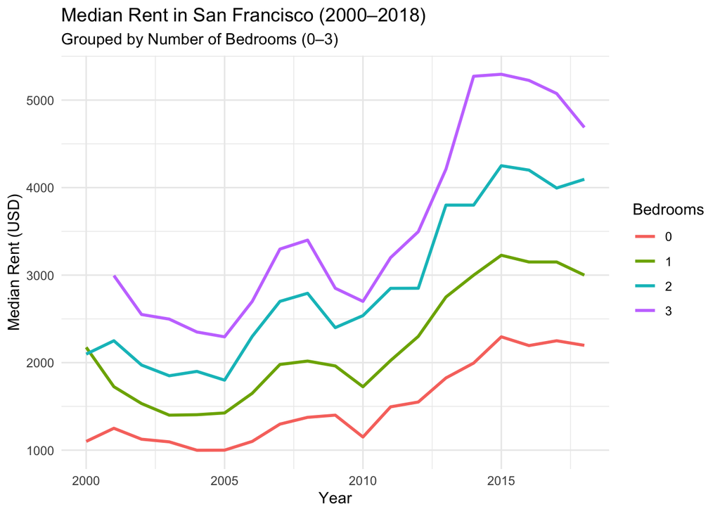

```r
sf_prices <- rent %>%
  filter(
    city == "san francisco",
    beds %in% 0:3,
    !is.na(price),
    !is.na(year)
  ) %>%
  group_by(year, beds) %>%
  summarise(median_price = median(price, na.rm = TRUE), .groups = "drop")

# Plot
ggplot(sf_prices, aes(x = year, y = median_price, color = as.factor(beds))) +
  geom_line(size = 1) +
  labs(
    title = "Median Rent in San Francisco (2000–2018)",
    subtitle = "Grouped by Number of Bedrooms (0–3)",
    x = "Year", y = "Median Rent (USD)",
    color = "Bedrooms"
  ) +
  theme_minimal()
```

Finally, make a plot that shows median rental prices for one-bed flats in the top 12 cities (by number of ads) in the Bay area. Your final graph should look like this

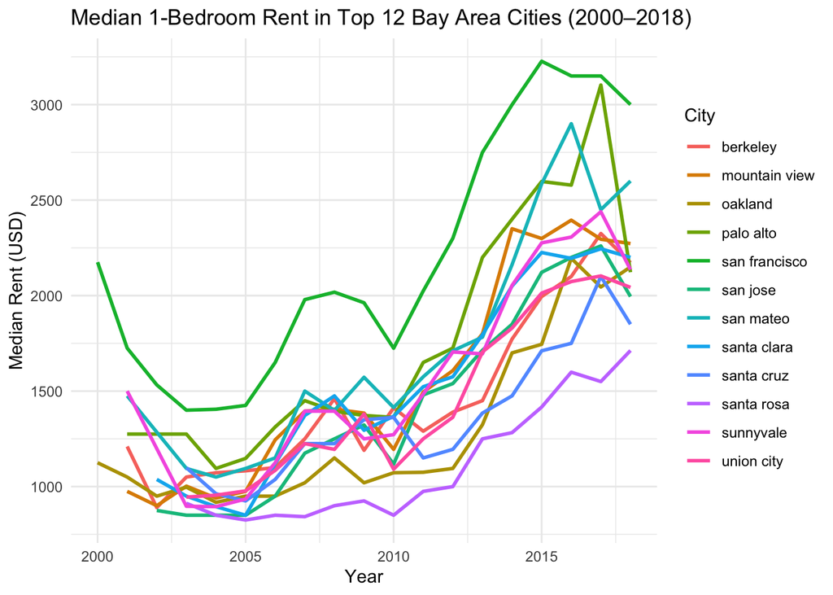

```r
# Step 1: Get top 12 cities by total listings
top_12_cities <- rent %>%
  count(city, sort = TRUE) %>%
  slice_max(n, n = 12) %>%
  pull(city)

# Step 2: Filter to 1-bedroom listings in those cities
one_bed_prices <- rent %>%
  filter(
    city %in% top_12_cities,
    beds == 1,
    !is.na(price),
    !is.na(year)
  ) %>%
  group_by(city, year) %>%
  summarise(median_price = median(price, na.rm = TRUE), .groups = "drop")

# Step 3: Plot
ggplot(one_bed_prices, aes(x = year, y = median_price, color = city)) +
  geom_line(size = 1) +
  labs(
    title = "Median 1-Bedroom Rent in Top 12 Bay Area Cities (2000–2018)",
    x = "Year", y = "Median Rent (USD)",
    color = "City"
  ) +
  theme_minimal()
```

What can you infer from these plots? Don’t just explain what’s in the graph, but speculate or tell a short story (1-2 paragraphs max).

The synchronized upward trends suggest that price pressures are spreading outward, making it harder for lower-income renters to find affordable housing, even in traditionally less expensive cities. This supports the idea that housing issues are regional, not just local to San Francisco.

## 2.1 Challenge

Filter the listings to those with good lat and lon values.

Optionally use round coordates or neighborhoods for more visually pleasing plotting.

Compute median rent by location and year.

Plot price as color intensity over time using ggplot2 and geom_tile() or geom_point().

It would be cool to either use facet_wrap(~ year), or animate the year dimension and see change.

If you’re looking for something more advanced, I would probably use sf, ggmap, leaflet or something similar to make an interactive or geographic map visualizing rent heat across the regions mentioned in this article.

# 3 Deliverables

There is a lot of explanatory text, comments, etc. You do not need these, so delete them and produce a stand-alone document that you could share with someone. Render the edited and completed Quarto Markdown (qmd) file as a Word document (use the “Render” button at the top of the script editor window) and upload it to Canvas. You must be commiting and pushing tour changes to your own Github repo as you go along.

# 4 Details

- Who did you collaborate with: N/A
- Approximately how much time did you spend on this problem set: 3 hours
- What, if anything, gave you the most trouble: N/A

**Please seek out help when you need it,** and remember the [15-minute rule](https://mam2022.netlify.app/syllabus/#the-15-minute-rule). You know enough R (and have enough examples of code from class and your readings) to be able to do this. If you get stuck, ask for help from others, post a question on Slack– and remember that I am here to help too!

> As a true test to yourself, do you understand the code you submitted and are you able to explain it to someone else?

Yes

# 5 Rubric

13/13: Problem set is 100% completed. Every question was attempted and answered, and most answers are correct. Code is well-documented (both self-documented and with additional comments as necessary). Used tidyverse, instead of base R. Graphs and tables are properly labelled. Analysis is clear and easy to follow, either because graphs are labeled clearly or you’ve written additional text to describe how you interpret the output. Multiple Github commits. Work is exceptional. I will not assign these often.

8/13: Problem set is 60–80% complete and most answers are correct. This is the expected level of performance. Solid effort. Hits all the elements. No clear mistakes. Easy to follow (both the code and the output). A few Github commits.

5/13: Problem set is less than 60% complete and/or most answers are incorrect. This indicates that you need to improve next time. I will hopefully not assign these often. Displays minimal effort. Doesn’t complete all components. Code is poorly written and not documented. Uses the same type of plot for each graph, or doesn’t use plots appropriate for the variables being analyzed. No Github commits.